# Dipping toes in Mixed Effects Modelling in R

## Nested model

```r
mixed.nested<- lmer(testScore ~ bodyLength + (1|mountainRange)+(1|sampling_site), data = dragons)
summary(mixed.nested)
```

```
## Linear mixed model fit by REML. t-tests use Satterthwaite's method [
## lmerModLmerTest]
## Formula: testScore ~ bodyLength + (1 | mountainRange) + (1 | sampling_site)
##    Data: dragons
##
## REML criterion at convergence: 3976
##
## Scaled residuals:
##     Min      1Q  Median      3Q     Max
## -3.2425 -0.6752 -0.0117  0.6974  2.8812
##
## Random effects:
##  Groups        Name        Variance Std.Dev.
##  sampling_site (Intercept)  23.09    4.805
##  mountainRange (Intercept) 327.56   18.099
##  Residual                  208.58   14.442
## Number of obs: 480, groups:  sampling_site, 24; mountainRange, 8
##
## Fixed effects:
##             Estimate Std. Error       df t value Pr(>|t|)
## (Intercept) 40.06668   21.86373 90.35454   1.833   0.0702 .
## bodyLength   0.05126    0.10368 94.18716   0.494   0.6222
## ---
## Signif. codes:  0 '***' 0.001 '**' 0.01 '*' 0.05 '.' 0.1 ' ' 1
##
## Correlation of Fixed Effects:
##            (Intr)
## bodyLength -0.955
```

lmer function is smart enough to notice that sampling_site is nested under mountainRange, but it’s always a good practice to write your model like this

```r
mixed.nested<- lmer(testScore ~ bodyLength + (1|mountainRange/sampling_site), data = dragons)
summary(mixed.nested)
```

```
## Linear mixed model fit by REML. t-tests use Satterthwaite's method [
## lmerModLmerTest]
## Formula: testScore ~ bodyLength + (1 | mountainRange/sampling_site)
##    Data: dragons
##
## REML criterion at convergence: 3976
##
## Scaled residuals:
##     Min      1Q  Median      3Q     Max
## -3.2425 -0.6752 -0.0117  0.6974  2.8812
##
## Random effects:
##  Groups                      Name        Variance Std.Dev.
##  sampling_site:mountainRange (Intercept)  23.09    4.805
##  mountainRange               (Intercept) 327.56   18.099
##  Residual                                208.58   14.442
## Number of obs: 480, groups:  sampling_site:mountainRange, 24; mountainRange, 8
##
## Fixed effects:
##             Estimate Std. Error       df t value Pr(>|t|)
## (Intercept) 40.06668   21.86373 90.35454   1.833   0.0702 .
## bodyLength   0.05126    0.10368 94.18716   0.494   0.6222
## ---
## Signif. codes:  0 '***' 0.001 '**' 0.01 '*' 0.05 '.' 0.1 ' ' 1
##
## Correlation of Fixed Effects:
##            (Intr)
## bodyLength -0.955
```

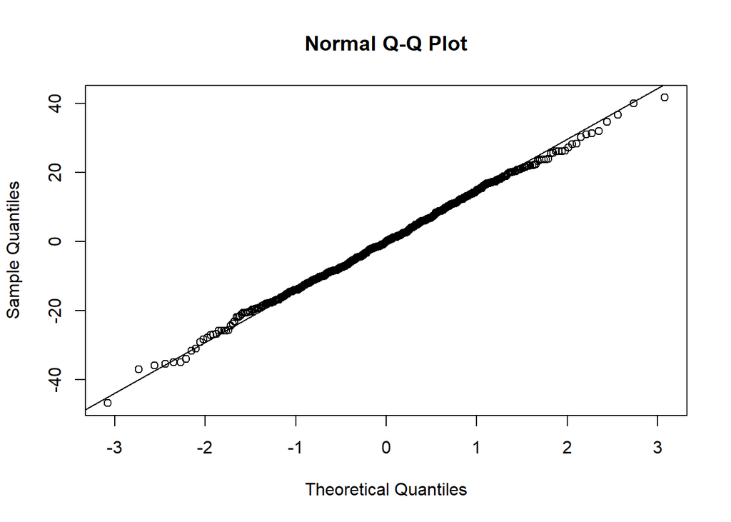

```r
qqnorm(resid(mixed.nested))
qqline(resid(mixed.nested))
```

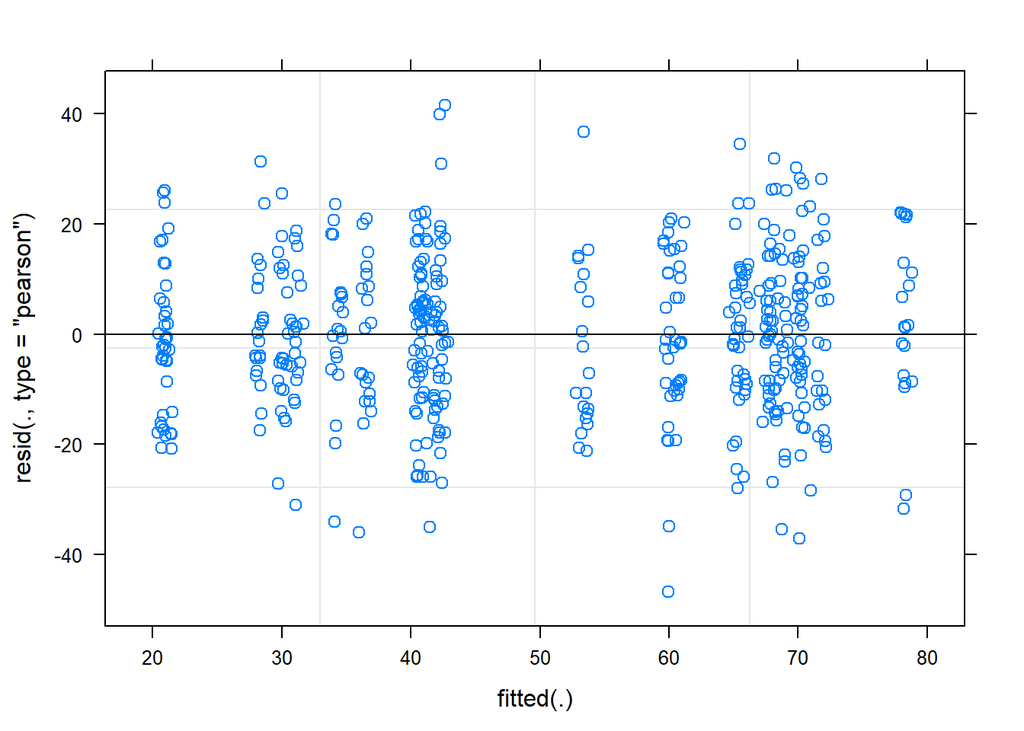

```r
plot(mixed.nested)
```

AIC=deviance+2∗(p+1) where p is # of parameters

```r
anova(mixed.intercept,mixed.nested,refit=FALSE)
```

|  | Df | AIC | BIC | logLik | deviance | Chisq | Chi Df | Pr(>Chisq) |
| --- | --- | --- | --- | --- | --- | --- | --- | --- |
| mixed.intercept | 4 | 3999.203 | 4015.898 | -1995.601 | 3991.203 | NA | NA | NA |
| mixed.nested | 5 | 3985.961 | 4006.830 | -1987.980 | 3975.961 | 15.2417 | 1 | 9.459172e-05 |

When comparing different random effects: `In lmer(), REML = TRUE (default),`In anova(), refit = FALSE

## Plot the model fit

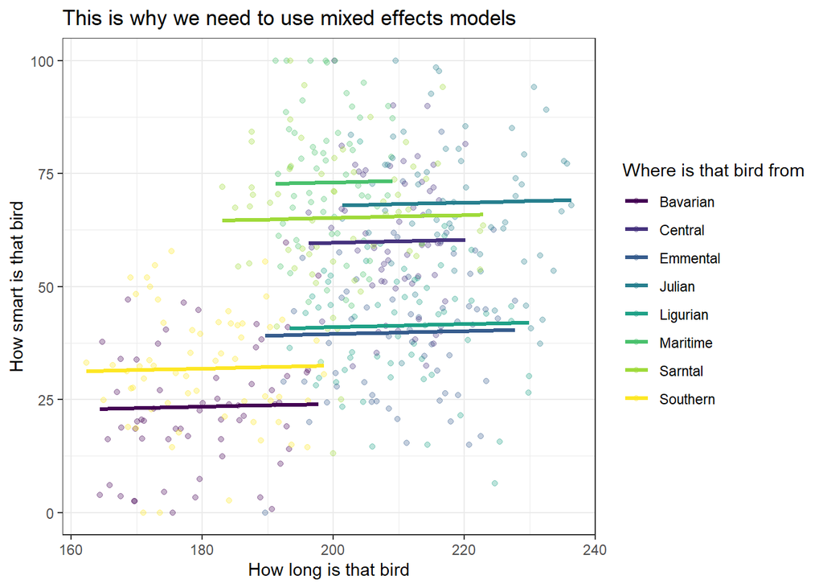

```r
dragons$fit <-predict(mixed.intercept)

dragons %>%
  mutate(fit=predict(mixed.intercept)) %>%
  ggplot(.,aes(bodyLength,testScore,group=mountainRange,col=mountainRange))+
  geom_point(alpha = .3,size=1.5)+
  theme_bw()+
  scale_color_viridis(discrete = T,)+
  geom_line(aes(y=fit),size = 1.2)+
  labs(x="How long is that bird",
      y="How smart is that bird",
      color = "Where is that bird from")+
  ggtitle("This is why we need to use mixed effects models")
```

## what do we make out of these results?

- Body length does NOT have an significant effect on test score.
- there’s something in that mountain varying both body length and test score…!

# Sleep study

The data is included in lme4 package

```r
head(sleepstudy)
```

|  | Reaction | Days | Subject |
| --- | --- | --- | --- |
| 1 | 249.5600 | 0 | 308 |
| 2 | 258.7047 | 1 | 308 |
| 3 | 250.8006 | 2 | 308 |
| 4 | 321.4398 | 3 | 308 |
| 5 | 356.8519 | 4 | 308 |
| 6 | 414.6901 | 5 | 308 |

```r
str(sleepstudy)
```

```
## 'data.frame':    180 obs. of  3 variables:
##  $ Reaction: num  250 259 251 321 357 ...
##  $ Days    : num  0 1 2 3 4 5 6 7 8 9 ...
##  $ Subject : Factor w/ 18 levels "308","309","310",..: 1 1 1 1 1 1 1 1 1 1 ...
```

VISUALIZE

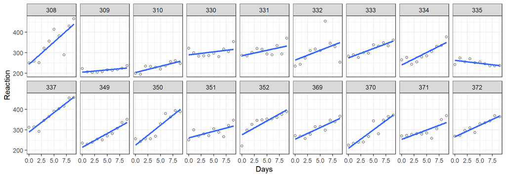

```r
sleepstudy %>%
  ggplot(.,aes(Days,Reaction))+
  facet_wrap(~Subject,nrow = 2)+
  geom_point(shape = 21)+
  geom_smooth(method = "lm",se = F)+
  theme_bw()
```

```r
sleep.lm <- lm(Reaction ~ Days, sleepstudy)
summary(sleep.lm)
```

```
##
## Call:
## lm(formula = Reaction ~ Days, data = sleepstudy)
##
## Residuals:
##      Min       1Q   Median       3Q      Max
## -110.848  -27.483    1.546   26.142  139.953
##
## Coefficients:
##             Estimate Std. Error t value Pr(>|t|)
## (Intercept)  251.405      6.610  38.033  < 2e-16 ***
## Days          10.467      1.238   8.454 9.89e-15 ***
## ---
## Signif. codes:  0 '***' 0.001 '**' 0.01 '*' 0.05 '.' 0.1 ' ' 1
##
## Residual standard error: 47.71 on 178 degrees of freedom
## Multiple R-squared:  0.2865, Adjusted R-squared:  0.2825
## F-statistic: 71.46 on 1 and 178 DF,  p-value: 9.894e-15
```

```r
sleep.intercept <- lmer(Reaction ~ Days + (1| Subject), sleepstudy)
summary(sleep.intercept)
```

```
## Linear mixed model fit by REML. t-tests use Satterthwaite's method [
## lmerModLmerTest]
## Formula: Reaction ~ Days + (1 | Subject)
##    Data: sleepstudy
##
## REML criterion at convergence: 1786.5
##
## Scaled residuals:
##     Min      1Q  Median      3Q     Max
## -3.2257 -0.5529  0.0109  0.5188  4.2506
##
## Random effects:
##  Groups   Name        Variance Std.Dev.
##  Subject  (Intercept) 1378.2   37.12
##  Residual              960.5   30.99
## Number of obs: 180, groups:  Subject, 18
##
## Fixed effects:
##             Estimate Std. Error       df t value Pr(>|t|)
## (Intercept) 251.4051     9.7467  22.8102   25.79   <2e-16 ***
## Days         10.4673     0.8042 161.0000   13.02   <2e-16 ***
## ---
## Signif. codes:  0 '***' 0.001 '**' 0.01 '*' 0.05 '.' 0.1 ' ' 1
##
## Correlation of Fixed Effects:
##      (Intr)
## Days -0.371
```

NOTE: in many cases, models may fail to converge (meaning the model is sh**) when you are trying to fit random slope, because fitting random slope requires a large sample size.

Don’t worry… RED warning message will tell you when it fails to converge.

Harrison et al., (2018): “fitting the most complex mixed effects structrue allowed by your data by”

1. fitting random slopes but removing the correlation between interecepts and slopes
2. fitting no random slopes at all but accepting that this inflates the Type I error rate

```r
sleep.slope <- lmer(Reaction ~ Days + (Days | Subject), sleepstudy)
summary(sleep.intercept)
```

```
## Linear mixed model fit by REML. t-tests use Satterthwaite's method [
## lmerModLmerTest]
## Formula: Reaction ~ Days + (1 | Subject)
##    Data: sleepstudy
##
## REML criterion at convergence: 1786.5
##
## Scaled residuals:
##     Min      1Q  Median      3Q     Max
## -3.2257 -0.5529  0.0109  0.5188  4.2506
##
## Random effects:
##  Groups   Name        Variance Std.Dev.
##  Subject  (Intercept) 1378.2   37.12
##  Residual              960.5   30.99
## Number of obs: 180, groups:  Subject, 18
##
## Fixed effects:
##             Estimate Std. Error       df t value Pr(>|t|)
## (Intercept) 251.4051     9.7467  22.8102   25.79   <2e-16 ***
## Days         10.4673     0.8042 161.0000   13.02   <2e-16 ***
## ---
## Signif. codes:  0 '***' 0.001 '**' 0.01 '*' 0.05 '.' 0.1 ' ' 1
##
## Correlation of Fixed Effects:
##      (Intr)
## Days -0.371
```

```r
sleep.slope.no.correlation <- lmer(Reaction ~ Days + ( Days || Subject), sleepstudy)
summary(sleep.slope.no.correlation)
```

```
## Linear mixed model fit by REML. t-tests use Satterthwaite's method [
## lmerModLmerTest]
## Formula: Reaction ~ Days + (Days || Subject)
##    Data: sleepstudy
##
## REML criterion at convergence: 1743.7
##
## Scaled residuals:
##     Min      1Q  Median      3Q     Max
## -3.9626 -0.4626  0.0204  0.4653  5.1860
##
## Random effects:
##  Groups    Name        Variance Std.Dev.
##  Subject   (Intercept) 627.50   25.050
##  Subject.1 Days         35.86    5.989
##  Residual              653.58   25.565
## Number of obs: 180, groups:  Subject, 18
##
## Fixed effects:
##             Estimate Std. Error      df t value Pr(>|t|)
## (Intercept)  251.405      6.885  18.158  36.514  < 2e-16 ***
## Days          10.467      1.560  18.153   6.711  2.6e-06 ***
## ---
## Signif. codes:  0 '***' 0.001 '**' 0.01 '*' 0.05 '.' 0.1 ' ' 1
##
## Correlation of Fixed Effects:
##      (Intr)
## Days -0.184
```

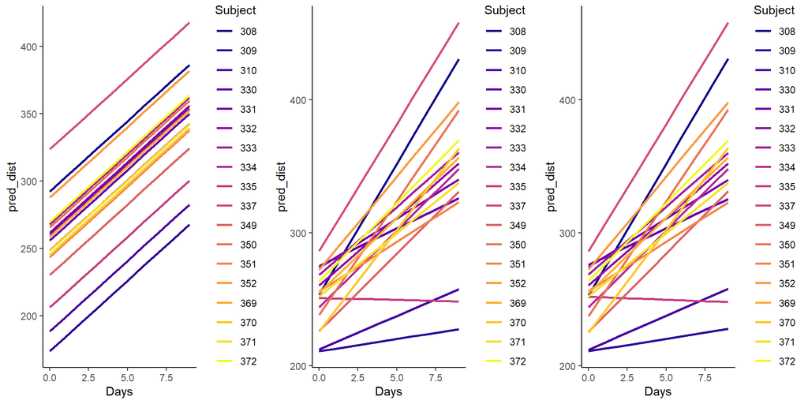

```r
p1 <- sleepstudy %>%
  mutate(pred_dist = fitted(sleep.intercept)) %>%
  ggplot(.,aes(Days, pred_dist, col = Subject))+
  theme_classic()+
  geom_line(size = 1)+
  scale_color_viridis(discrete = T,option = "C")

p2 <- sleepstudy %>%
  mutate(pred_dist = fitted(sleep.slope)) %>%
  ggplot(.,aes(Days, pred_dist, col = Subject))+
  theme_classic()+
  geom_line(size = 1)+
  scale_color_viridis(discrete = T,option = "C")

p3 <- sleepstudy %>%
  mutate(pred_dist = fitted(sleep.slope.no.correlation)) %>%
  ggplot(.,aes(Days, pred_dist, col = Subject))+
  theme_classic()+
  geom_line(size = 1)+
  scale_color_viridis(discrete = T,option = "C")

gridExtra::grid.arrange(p1,p2,p3,nrow=1)
```

```r
anova(sleep.intercept,sleep.slope, sleep.slope.no.correlation, refit = FALSE)
```

|  | Df | AIC | BIC | logLik | deviance | Chisq | Chi Df | Pr(>Chisq) |
| --- | --- | --- | --- | --- | --- | --- | --- | --- |
| sleep.intercept | 4 | 1794.465 | 1807.237 | -893.2325 | 1786.465 | NA | NA | NA |
| sleep.slope.no.correlation | 5 | 1753.669 | 1769.634 | -871.8346 | 1743.669 | 42.79579160 | 1 | 6.076274e-11 |
| sleep.slope | 6 | 1755.628 | 1774.786 | -871.8141 | 1743.628 | 0.04102092 | 1 | 8.394975e-01 |

# Wheels lol

```r
df <- read.csv("wheels.csv")
head(df)
```

|  | id | day1 | day2 | day3 | day4 | dob | mother | sex | strain | wheel | startdate |
| --- | --- | --- | --- | --- | --- | --- | --- | --- | --- | --- | --- |
| 1 | 637au | 4175.0 | 1975.0 | 1670.0 | 1636.0 | 13.11.04 | 574ac | male | S129 | 8 | 20.09.05 |
| 2 | 637az | 4243.5 | 906.0 | 1233.0 | 1270.5 | 13.11.04 | 572af | male | S129 | 4 | 05.09.05 |
| 3 | 656aa | 2644.0 | 4011.5 | 5237.0 | 7404.5 | 16.12.04 | 593ar | male | B6 | 1 | 12.09.05 |
| 4 | 656af | 6906.5 | 5322.5 | 10424.5 | 8468.5 | 16.12.04 | 593ar | male | B6 | 2 | 13.10.05 |
| 5 | 656al | 6517.0 | 4440.0 | 5333.5 | 9291.0 | 19.12.04 | 554aa | male | B6 | 8 | 09.10.05 |
| 6 | 675ag | 4003.5 | 3053.5 | 3815.5 | 3761.0 | 09.02.05 | 593ad | male | B6 | 5 | 13.10.05 |

```r
df1 <- df %>%
  gather(day,rev,2:5) %>%
  mutate(day = as.numeric(str_sub(day,4)))
head(df1)
```

|  | id | dob | mother | sex | strain | wheel | startdate | day | rev |
| --- | --- | --- | --- | --- | --- | --- | --- | --- | --- |
| 1 | 637au | 13.11.04 | 574ac | male | S129 | 8 | 20.09.05 | 1 | 4175.0 |
| 2 | 637az | 13.11.04 | 572af | male | S129 | 4 | 05.09.05 | 1 | 4243.5 |
| 3 | 656aa | 16.12.04 | 593ar | male | B6 | 1 | 12.09.05 | 1 | 2644.0 |
| 4 | 656af | 16.12.04 | 593ar | male | B6 | 2 | 13.10.05 | 1 | 6906.5 |
| 5 | 656al | 19.12.04 | 554aa | male | B6 | 8 | 09.10.05 | 1 | 6517.0 |
| 6 | 675ag | 09.02.05 | 593ad | male | B6 | 5 | 13.10.05 | 1 | 4003.5 |

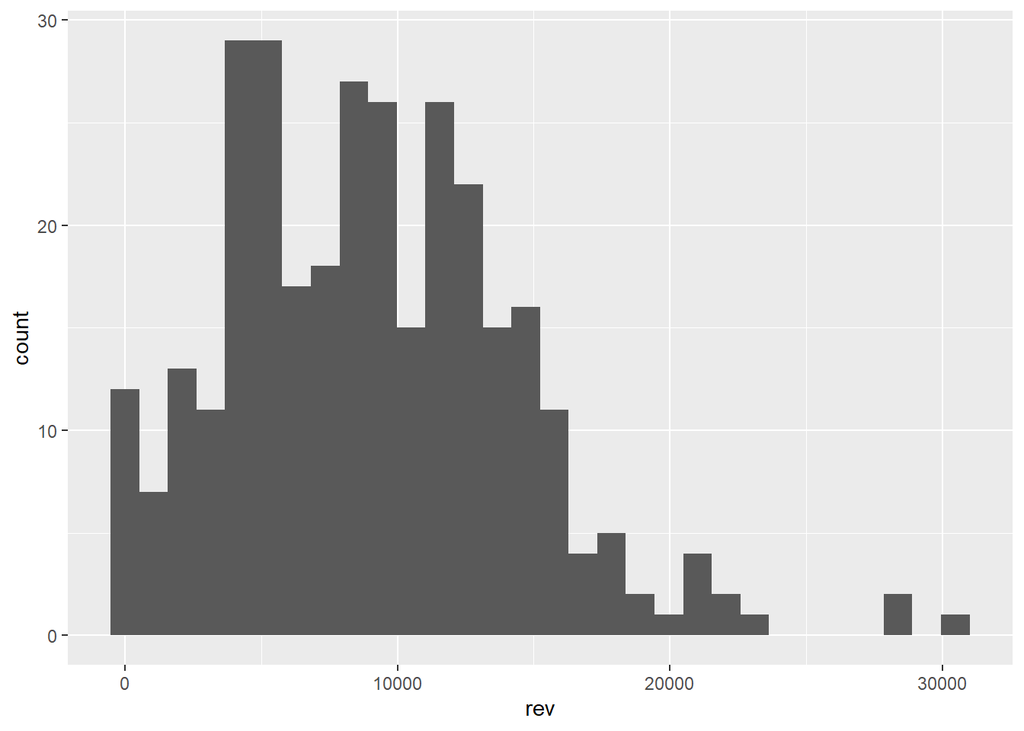

```r
df1 %>%
  ggplot(.,aes(rev))+
  geom_histogram()
```

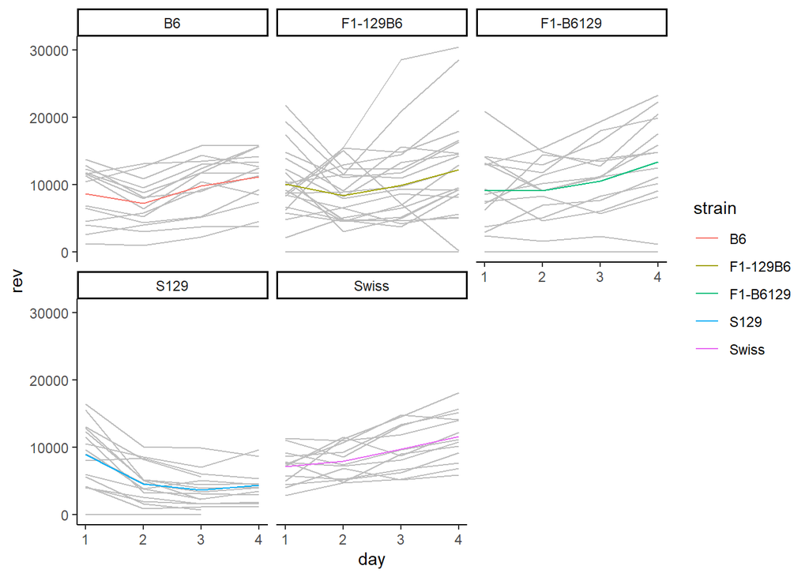

```r
df1 %>%
  ggplot(.,aes(day,rev, group = id))+
  geom_line(color = "grey")+
  geom_line(data = df1 %>%
              group_by(strain,day) %>%
              summarize(avg = mean(rev,na.rm = T)),
            aes(day,avg,color=strain,group = strain))+
  facet_wrap(~strain)+
  theme_classic()
```

```r
mod0 <- lmer(rev ~ 1 + (day||id), data = df1, REML = F)

mod1 <- lmer(rev ~ strain*day + (day||id), data = df1, REML = F)

summary(mod1)
```

```
## Linear mixed model fit by maximum likelihood . t-tests use Satterthwaite's
##   method [lmerModLmerTest]
## Formula: rev ~ strain * day + (day || id)
##    Data: df1
##
##      AIC      BIC   logLik deviance df.resid
##   6085.8   6134.6  -3029.9   6059.8      303
##
## Scaled residuals:
##      Min       1Q   Median       3Q      Max
## -2.76000 -0.51643 -0.08685  0.44803  3.16049
##
## Random effects:
##  Groups   Name        Variance Std.Dev.
##  id       (Intercept) 9094354  3016
##  id.1     day         1234140  1111
##  Residual             5893940  2428
## Number of obs: 316, groups:  id, 80
##
## Fixed effects:
##                    Estimate Std. Error      df t value Pr(>|t|)
## (Intercept)          6720.5     1131.9   118.5   5.938 2.95e-08 ***
## strainF1-129B6       1424.3     1447.9   118.5   0.984   0.3272
## strainF1-B6129        216.5     1573.8   118.5   0.138   0.8908
## strainS129           2843.8     1565.6   122.7   1.816   0.0717 .
## strainSwiss         -1389.5     1631.2   118.5  -0.852   0.3960
## day                  1010.5      415.2   117.2   2.434   0.0164 *
## strainF1-129B6:day   -197.1      531.1   117.2  -0.371   0.7112
## strainF1-B6129:day    431.5      577.2   117.2   0.748   0.4562
## strainS129:day      -2779.1      583.8   124.5  -4.761 5.26e-06 ***
## strainSwiss:day       514.4      598.3   117.2   0.860   0.3917
## ---
## Signif. codes:  0 '***' 0.001 '**' 0.01 '*' 0.05 '.' 0.1 ' ' 1
##
## Correlation of Fixed Effects:
##             (Intr) stF1-129B6 stF1-B6129 stS129 strnSw day    sF1-129B6:
## strF1-129B6 -0.782
## strF1-B6129 -0.719  0.562
## strainS129  -0.723  0.565      0.520
## strainSwiss -0.694  0.542      0.499      0.502
## day         -0.448  0.350      0.322      0.324  0.311
## stF1-129B6:  0.350 -0.448     -0.252     -0.253 -0.243 -0.782
## stF1-B6129:  0.322 -0.252     -0.448     -0.233 -0.224 -0.719  0.562
## strnS129:dy  0.319 -0.249     -0.229     -0.464 -0.221 -0.711  0.556
## strnSwss:dy  0.311 -0.243     -0.224     -0.225 -0.448 -0.694  0.542
##             sF1-B6129: sS129:
## strF1-129B6
## strF1-B6129
## strainS129
## strainSwiss
## day
## stF1-129B6:
## stF1-B6129:
## strnS129:dy  0.511
## strnSwss:dy  0.499      0.493
```

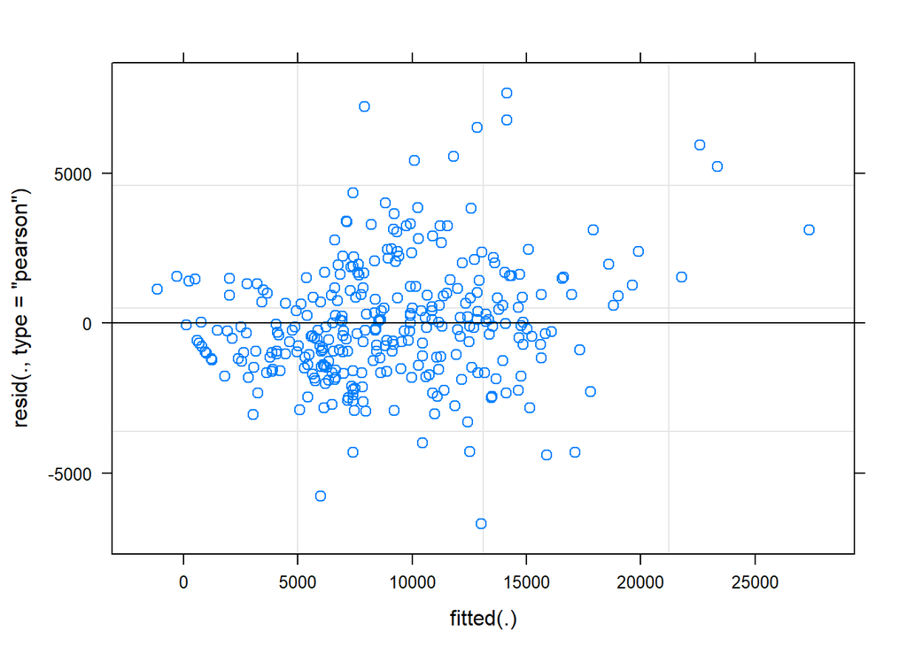

```r
plot(mod1)
```

```r
anova(mod0,mod1)
```

|  | Df | AIC | BIC | logLik | deviance | Chisq | Chi Df | Pr(>Chisq) |
| --- | --- | --- | --- | --- | --- | --- | --- | --- |
| mod0 | 4 | 6116.465 | 6131.488 | -3054.233 | 6108.465 | NA | NA | NA |
| mod1 | 13 | 6085.790 | 6134.615 | -3029.895 | 6059.790 | 48.67539 | 9 | 1.909335e-07 |

```r
library(MCMCglmm)
df2 <- df1 %>%
  mutate(id = as.character(id))


mcmc.mod <- MCMCglmm(rev ~ day*strain,
                      random = ~idh(day):id,
                      family = "gaussian",
                      data = df2,
                      verbose = F)

summary(mcmc.mod)
```

```
##
##  Iterations = 3001:12991
##  Thinning interval  = 10
##  Sample size  = 1000
##
##  DIC: 6014.07
##
##  G-structure:  ~idh(day):id
##
##        post.mean l-95% CI u-95% CI eff.samp
## day.id   2146866  1420953  2979725     1000
##
##  R-structure:  ~units
##
##       post.mean l-95% CI u-95% CI eff.samp
## units   8532513  6990737 10051198     1000
##
##  Location effects: rev ~ day * strain
##
##                    post.mean l-95% CI u-95% CI eff.samp  pMCMC
## (Intercept)          6697.72  4734.26  8572.94   1000.0 <0.001 ***
## day                  1020.05    13.39  1980.11   1000.0  0.040 *
## strainF1-129B6       1472.20  -878.14  3887.07    798.3  0.238
## strainF1-B6129        262.31 -2371.03  2660.43   1172.6  0.848
## strainS129           2862.07   -18.20  5553.54   1000.0  0.038 *
## strainSwiss         -1368.63 -3976.64  1285.99    824.2  0.322
## day:strainF1-129B6   -217.25 -1522.58  1118.75    880.2  0.754
## day:strainF1-B6129    401.49 -1017.12  1804.15   1129.8  0.602
## day:strainS129      -2772.30 -4149.35 -1251.37    906.8 <0.001 ***
## day:strainSwiss       494.46  -958.27  1905.09    854.9  0.506
## ---
## Signif. codes:  0 '***' 0.001 '**' 0.01 '*' 0.05 '.' 0.1 ' ' 1
```

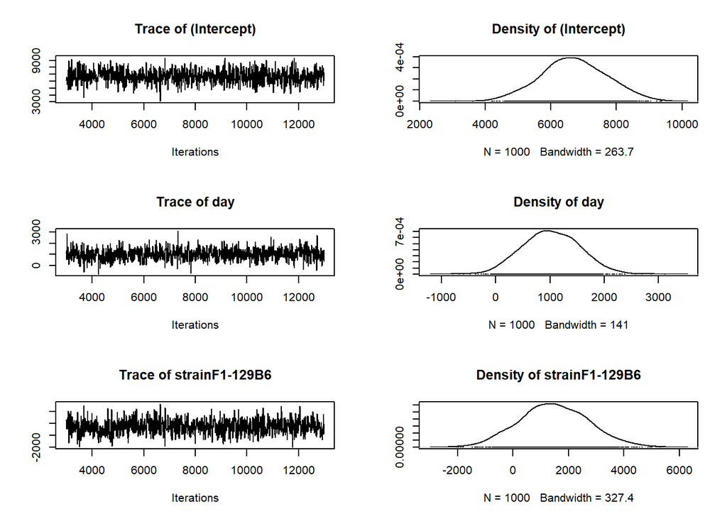

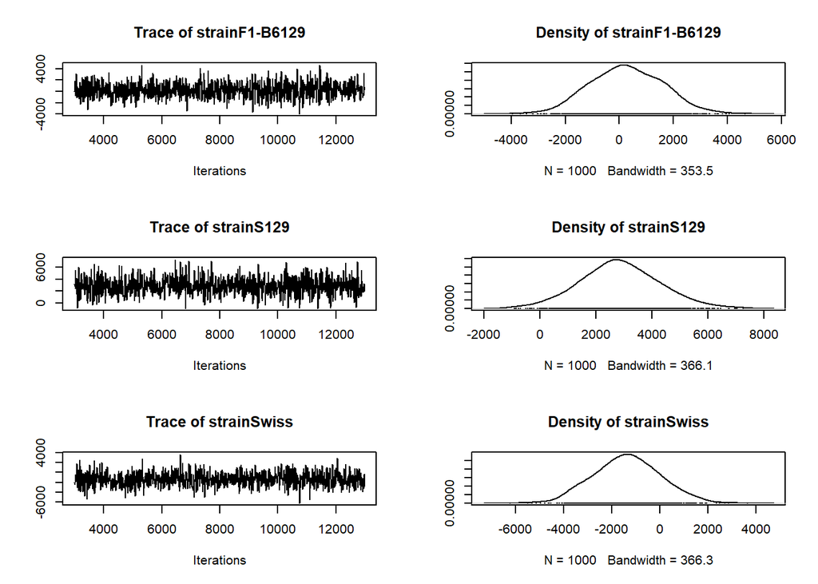

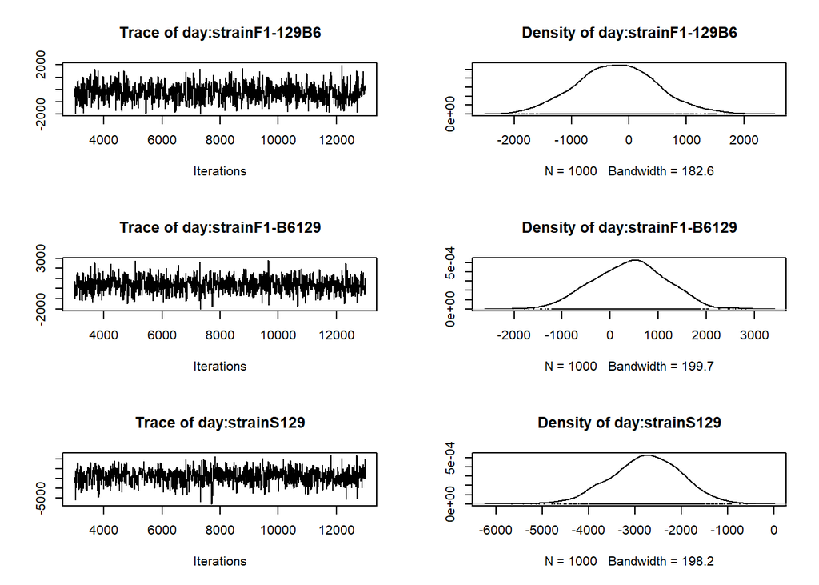

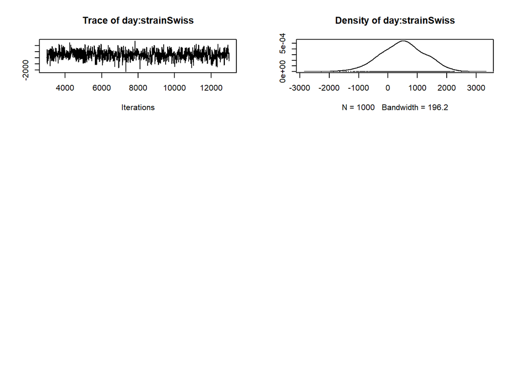

```r
plot(mcmc.mod$Sol)
```